# BankChurnPredictionNN

Objective: Given a Bank customer, build a neural network-based classifier that can determine whether they will leave or not in the next 6 months. Context: Businesses like banks that provide service have to worry about the problem of 'Churn' i.e. customers leaving and joining another service provider. It is important to understand which aspects of the service influence a customer's decision in this regard. Management can concentrate efforts on the improvement of service, keeping in mind these priorities. Data Description: The case study is from an open-source dataset from Kaggle. The dataset contains 10,000 sample points with 14 distinct features such as CustomerId, CreditScore, Geography, Gender, Age, Tenure, Balance, etc. Link to the Kaggle project site:https://www.kaggle.com/barelydedicated/bank-customer-churn-modeling Data Dictionary: RowNumber: Row number. CustomerId: Unique identification key for different customers. Surname: Surname of the customer Credit Score: Credit score is a measure of an individual's ability to pay back the borrowed amount. It is the numerical representation of their creditworthiness. A credit score is a 3-digit number that falls in the range of 300-900, 900 being the highest. Geography: The country to which the customer belongs. Gender: The gender of the customer. Age: Age of the customer. Tenure: The period of time a customer has been associated with the bank. Balance: The account balance (the amount of money deposited in the bank account) of the customer. NumOfProducts: How many accounts, bank account affiliated products the person has. HasCrCard: Does the customer have a credit card through the bank? IsActiveMember: Subjective, but for the concept EstimatedSalary: Estimated salary of the customer. Exited: Did they leave the bank after all? Points Distribution: The points distribution for this case is as follows: 1. Read the dataset 2. Drop the columns which are unique for all users like IDs (5 points) 3. Perform bivariate analysis and give your insights from the same (5 points) 4. Distinguish the feature and target set and divide the data set into training and test sets (5 points) 5. Normalize the train and test data (10points) 6. Initialize & build the model. Identify the points of improvement and implement the same. (20) 7. Predict the results using 0.5 as a threshold (10points) 8. Print the Accuracy score and confusion matrix (5 points)

```python
import numpy as np
import tensorflow as tf
import pandas as pd
import matplotlib.pyplot as plt
import seaborn as sns
import pandas_profiling
from sklearn.preprocessing import LabelEncoder
from sklearn.preprocessing import StandardScaler


dataset = pd.read_csv('bank.csv')
dataset.head()
```

|  | RowNumber | CustomerId | Surname | CreditScore | Geography | Gender | Age | Tenure | Balance | NumOfProducts | HasCrCard | IsActiveMember | EstimatedSalary | Exited |
| --- | --- | --- | --- | --- | --- | --- | --- | --- | --- | --- | --- | --- | --- | --- |
| 0 | 1 | 15634602 | Hargrave | 619 | France | Female | 42 | 2 | 0.00 | 1 | 1 | 1 | 101348.88 | 1 |
| 1 | 2 | 15647311 | Hill | 608 | Spain | Female | 41 | 1 | 83807.86 | 1 | 0 | 1 | 112542.58 | 0 |
| 2 | 3 | 15619304 | Onio | 502 | France | Female | 42 | 8 | 159660.80 | 3 | 1 | 0 | 113931.57 | 1 |
| 3 | 4 | 15701354 | Boni | 699 | France | Female | 39 | 1 | 0.00 | 2 | 0 | 0 | 93826.63 | 0 |
| 4 | 5 | 15737888 | Mitchell | 850 | Spain | Female | 43 | 2 | 125510.82 | 1 | 1 | 1 | 79084.10 | 0 |

```python
dataset['CustomerId'].is_unique
```

```
True
```

Since the customer Id is unique it is ok to drop that, as the value is of no consequence this means that RowNumber CustomerId Surname are all expendable. Will drop them

```python
dataset.shape
```

```
(10000, 14)
```

```python
dataset.isna().sum()
```

```
RowNumber          0
CustomerId         0
Surname            0
CreditScore        0
Geography          0
Gender             0
Age                0
Tenure             0
Balance            0
NumOfProducts      0
HasCrCard          0
IsActiveMember     0
EstimatedSalary    0
Exited             0
dtype: int64
```

```python
dataset.describe().transpose()
```

|  | count | mean | std | min | 25% | 50% | 75% | max |
| --- | --- | --- | --- | --- | --- | --- | --- | --- |
| RowNumber | 10000.0 | 5.000500e+03 | 2886.895680 | 1.00 | 2500.75 | 5.000500e+03 | 7.500250e+03 | 10000.00 |
| CustomerId | 10000.0 | 1.569094e+07 | 71936.186123 | 15565701.00 | 15628528.25 | 1.569074e+07 | 1.575323e+07 | 15815690.00 |
| CreditScore | 10000.0 | 6.505288e+02 | 96.653299 | 350.00 | 584.00 | 6.520000e+02 | 7.180000e+02 | 850.00 |
| Age | 10000.0 | 3.892180e+01 | 10.487806 | 18.00 | 32.00 | 3.700000e+01 | 4.400000e+01 | 92.00 |
| Tenure | 10000.0 | 5.012800e+00 | 2.892174 | 0.00 | 3.00 | 5.000000e+00 | 7.000000e+00 | 10.00 |
| Balance | 10000.0 | 7.648589e+04 | 62397.405202 | 0.00 | 0.00 | 9.719854e+04 | 1.276442e+05 | 250898.09 |
| NumOfProducts | 10000.0 | 1.530200e+00 | 0.581654 | 1.00 | 1.00 | 1.000000e+00 | 2.000000e+00 | 4.00 |
| HasCrCard | 10000.0 | 7.055000e-01 | 0.455840 | 0.00 | 0.00 | 1.000000e+00 | 1.000000e+00 | 1.00 |
| IsActiveMember | 10000.0 | 5.151000e-01 | 0.499797 | 0.00 | 0.00 | 1.000000e+00 | 1.000000e+00 | 1.00 |
| EstimatedSalary | 10000.0 | 1.000902e+05 | 57510.492818 | 11.58 | 51002.11 | 1.001939e+05 | 1.493882e+05 | 199992.48 |
| Exited | 10000.0 | 2.037000e-01 | 0.402769 | 0.00 | 0.00 | 0.000000e+00 | 0.000000e+00 | 1.00 |

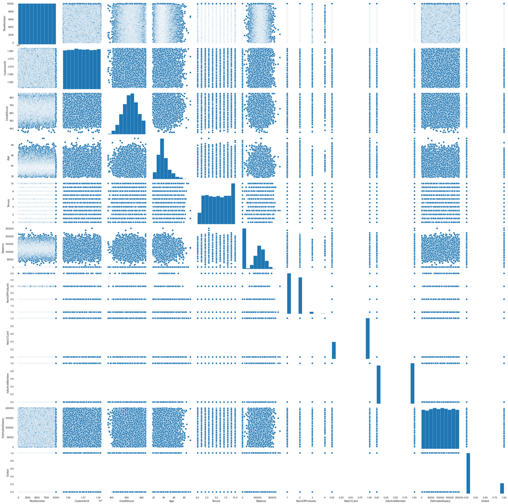

```python
sns.pairplot(dataset)
```

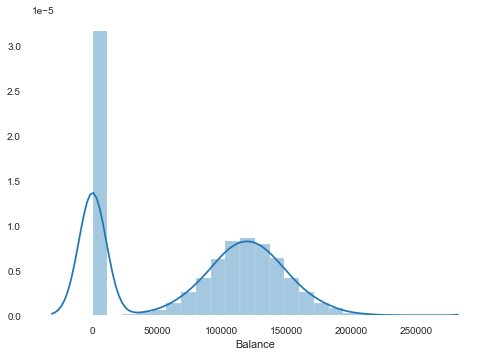

```python
sns.distplot(dataset.Balance)
plt.show()
```

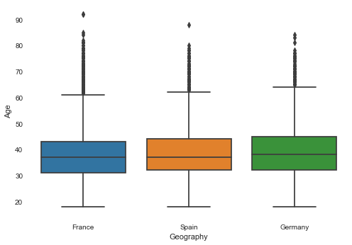

```python
sns.boxplot(data = dataset, x= 'Geography', y = 'Age')
plt.show()
```

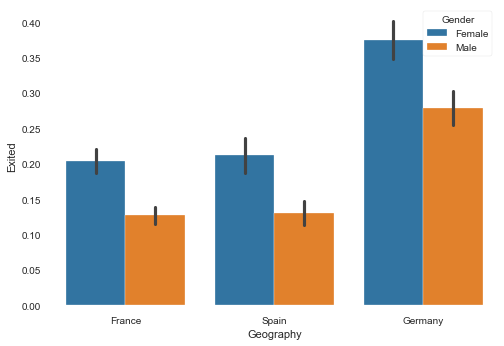

```python
sns.barplot(x="Geography", y="Exited", hue = 'Gender', data=dataset)
plt.show()
```

THIS SHOW THAT WOMEN LEAVE AT HIGHER RATE

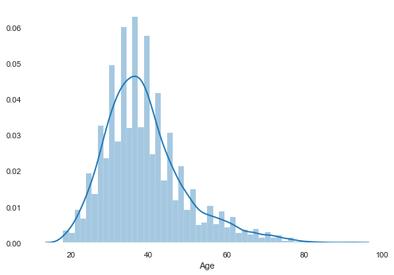

```python
sns.distplot(dataset.Age)
plt.show()
```

Looks like the Average age is just under 40

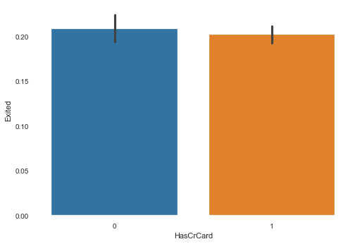

```python
sns.barplot(x="HasCrCard", y="Exited", data=dataset)
plt.show()
```

Having a card doesnt seem too much to do with exit

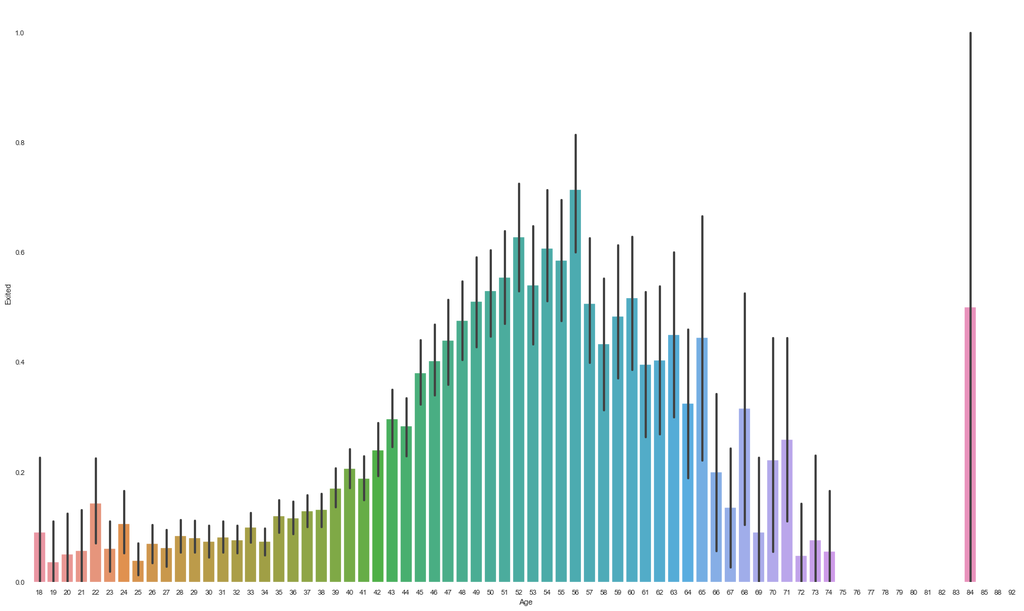

```python
plt.figure(figsize=(25,15))
sns.barplot(x="Age", y="Exited", data=dataset)
plt.show()
```

THERE IS SOME INCLINATION BETWEEN AGE AND EXIT, BUT NOT VERY CLEAR

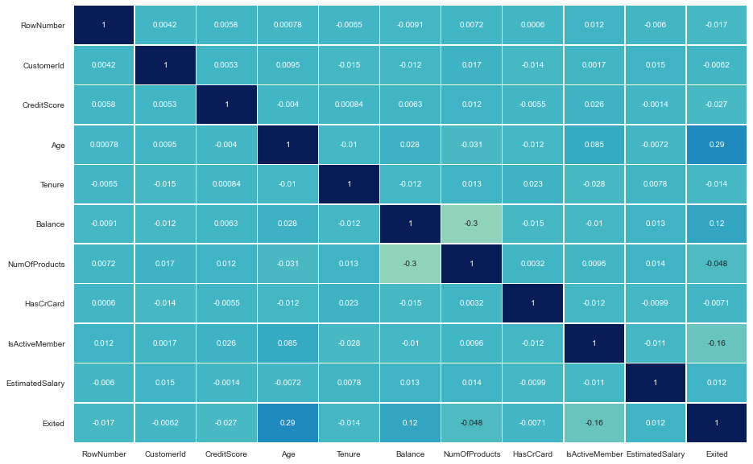

```python
plt.figure(figsize=(15,10))

sns.heatmap(dataset.corr(),
            annot=True,
            linewidths=.5,
            center=0,
            cbar=False,
            cmap="YlGnBu")

plt.show()
```

```python
dataset.head()
```

|  | RowNumber | CustomerId | Surname | CreditScore | Geography | Gender | Age | Tenure | Balance | NumOfProducts | HasCrCard | IsActiveMember | EstimatedSalary | Exited |
| --- | --- | --- | --- | --- | --- | --- | --- | --- | --- | --- | --- | --- | --- | --- |
| 0 | 1 | 15634602 | Hargrave | 619 | France | Female | 42 | 2 | 0.00 | 1 | 1 | 1 | 101348.88 | 1 |
| 1 | 2 | 15647311 | Hill | 608 | Spain | Female | 41 | 1 | 83807.86 | 1 | 0 | 1 | 112542.58 | 0 |
| 2 | 3 | 15619304 | Onio | 502 | France | Female | 42 | 8 | 159660.80 | 3 | 1 | 0 | 113931.57 | 1 |
| 3 | 4 | 15701354 | Boni | 699 | France | Female | 39 | 1 | 0.00 | 2 | 0 | 0 | 93826.63 | 0 |
| 4 | 5 | 15737888 | Mitchell | 850 | Spain | Female | 43 | 2 | 125510.82 | 1 | 1 | 1 | 79084.10 | 0 |

```python
from sklearn.preprocessing import OneHotEncoder
list(dataset.select_dtypes(include=['object']).columns)
```

```
['Surname', 'Geography', 'Gender']
```

```python
# Index starts at 0.
x = dataset.iloc[:, 3:-1].values

# Just get the last column of dataset for the dependent variable.
y = dataset.iloc[:, -1].values
```

```python
x[:, 2]
```

```
array(['Female', 'Female', 'Female', ..., 'Female', 'Male', 'Female'],
      dtype=object)
```

```python
le = LabelEncoder()
# Get all the rwos for the 2 column and encode them.
x[:, 2] = le.fit_transform(x[:, 2])
```

```python
x
```

```
array([[619, 'France', 0, ..., 1, 1, 101348.88],
       [608, 'Spain', 0, ..., 0, 1, 112542.58],
       [502, 'France', 0, ..., 1, 0, 113931.57],
       ...,
       [709, 'France', 0, ..., 0, 1, 42085.58],
       [772, 'Germany', 1, ..., 1, 0, 92888.52],
       [792, 'France', 0, ..., 1, 0, 38190.78]], dtype=object)
```

```python
# We do one hot coding for geographical places because they have no relation among themselves like gender did.
from sklearn.compose import ColumnTransformer
from sklearn.preprocessing import OneHotEncoder
ct = ColumnTransformer(transformers=[('encoder', OneHotEncoder(), [1])], remainder='passthrough')
```

```python
ct
```

```
ColumnTransformer(remainder='passthrough',
                  transformers=[('encoder', OneHotEncoder(), [1])])
```

```python
x = np.array(ct.fit_transform(x))
x
```

```
array([[1.0, 0.0, 0.0, ..., 1, 1, 101348.88],
       [0.0, 0.0, 1.0, ..., 0, 1, 112542.58],
       [1.0, 0.0, 0.0, ..., 1, 0, 113931.57],
       ...,
       [1.0, 0.0, 0.0, ..., 0, 1, 42085.58],
       [0.0, 1.0, 0.0, ..., 1, 0, 92888.52],
       [1.0, 0.0, 0.0, ..., 1, 0, 38190.78]], dtype=object)
```

```python
sc = StandardScaler()
```

```python
x = sc.fit_transform(x)
```

```python
print(x)
```

```
[[ 0.99720391 -0.57873591 -0.57380915 ...  0.64609167  0.97024255
   0.02188649]
 [-1.00280393 -0.57873591  1.74273971 ... -1.54776799  0.97024255
   0.21653375]
 [ 0.99720391 -0.57873591 -0.57380915 ...  0.64609167 -1.03067011
   0.2406869 ]
 ...
 [ 0.99720391 -0.57873591 -0.57380915 ... -1.54776799  0.97024255
  -1.00864308]
 [-1.00280393  1.72790383 -0.57380915 ...  0.64609167 -1.03067011
  -0.12523071]
 [ 0.99720391 -0.57873591 -0.57380915 ...  0.64609167 -1.03067011
  -1.07636976]]
```

```python
from sklearn.model_selection import train_test_split
from sklearn.model_selection import train_test_split
import tensorflow as tf
from sklearn import preprocessing
from tensorflow.keras.models import Sequential
from tensorflow.keras.layers import Dense, Dropout, BatchNormalization
from sklearn.metrics import accuracy_score, confusion_matrix, precision_score, recall_score, f1_score, precision_recall_curve, auc
import matplotlib.pyplot as plt
from tensorflow.keras import optimizers


X_train, X_test, y_train, y_test = train_test_split(x, y, test_size = 0.3, random_state = 10)
y_train
```

```
array([0, 0, 0, ..., 1, 0, 1])
```

```python
print(X_train.shape)
print(X_test.shape)
print(y_train.shape)
print(y_test.shape)
```

```
(7000, 12)
(3000, 12)
(7000,)
(3000,)
```

NN Part

```python
model = Sequential()
model.add(Dense(64, input_shape=(12,), activation = 'relu'))
model.add(Dense(32, activation = 'tanh'))
model.add(Dense(1, activation = 'sigmoid'))
sgd = optimizers.Adam(lr = 0.001)
model.compile(optimizer = sgd, loss = 'binary_crossentropy', metrics=['accuracy'])
model.summary()
```

```
Model: "sequential"
_________________________________________________________________
Layer (type)                 Output Shape              Param #
=================================================================
dense (Dense)                (None, 64)                832
_________________________________________________________________
dense_1 (Dense)              (None, 32)                2080
_________________________________________________________________
dense_2 (Dense)              (None, 1)                 33
=================================================================
Total params: 2,945
Trainable params: 2,945
Non-trainable params: 0
_________________________________________________________________
```

Evaluation Keras model can be evaluated with evaluate() function Evaluation results are contained in a list

```python
model.fit(X_train, y_train, batch_size = 700, epochs = 100, verbose = 1)
```

```
<tensorflow.python.keras.callbacks.History at 0x14c8aacd0>
```

```python
X_test = preprocessing.normalize(X_test)
results = model.evaluate(X_test, y_test)
print(model.metrics_names)
print(results)
```

```
['loss', 'accuracy']
[0.41392016410827637, 0.8026666641235352]
```

```python
Y_pred_cls = model.predict_classes(X_test, batch_size=200, verbose=0)
print('Accuracy Model1 (Dropout): '+ str(model.evaluate(X_test,y_test)[1]))
print('Recall_score: ' + str(recall_score(y_test,Y_pred_cls)))
print('Precision_score: ' + str(precision_score(y_test, Y_pred_cls)))
print('F-score: ' + str(f1_score(y_test,Y_pred_cls)))
confusion_matrix(y_test, Y_pred_cls)
```

```
Accuracy Model1 (Dropout): 0.8026666641235352
Recall_score: 0.06774193548387097
Precision_score: 0.75
F-score: 0.12426035502958581
```

```
array([[2366,   14],
       [ 578,   42]])
```

```python
model = Sequential()
model.add(Dense(192, input_shape=(12,), activation = 'elu'))
model.add(Dense(128, input_shape=(12,), activation = 'elu'))
model.add(Dense(64, input_shape=(12,), activation = 'elu'))
model.add(Dense(32, activation = 'tanh'))
model.add(Dense(1, activation = 'sigmoid'))
sgd = optimizers.Adam(lr = 0.001)
model.compile(optimizer = 'adam', loss = 'binary_crossentropy', metrics=['accuracy'])
model.summary()
```

```
Model: "sequential_1"
_________________________________________________________________
Layer (type)                 Output Shape              Param #
=================================================================
dense_3 (Dense)              (None, 192)               2496
_________________________________________________________________
dense_4 (Dense)              (None, 128)               24704
_________________________________________________________________
dense_5 (Dense)              (None, 64)                8256
_________________________________________________________________
dense_6 (Dense)              (None, 32)                2080
_________________________________________________________________
dense_7 (Dense)              (None, 1)                 33
=================================================================
Total params: 37,569
Trainable params: 37,569
Non-trainable params: 0
_________________________________________________________________
```

```python
model.fit(X_train, y_train, batch_size = 100, epochs = 300, verbose = 1)
X_test = preprocessing.normalize(X_test)
results = model.evaluate(X_test, y_test)
print(model.metrics_names)
print(results)
Y_pred_cls = model.predict_classes(X_test, batch_size=200, verbose=0)
print('Accuracy Model1 (Dropout): '+ str(model.evaluate(X_test,y_test)[1]))
print('Recall_score: ' + str(recall_score(y_test,Y_pred_cls)))
print('Precision_score: ' + str(precision_score(y_test, Y_pred_cls)))
print('F-score: ' + str(f1_score(y_test,Y_pred_cls)))
confusion_matrix(y_test, Y_pred_cls)
```

```
['loss', 'accuracy']
[1.058537483215332, 0.7603333592414856]
```

```
Accuracy Model1 (Dropout): 0.7603333592414856
Recall_score: 0.14516129032258066
Precision_score: 0.3225806451612903
F-score: 0.20022246941045604
```

```
array([[2191,  189],
       [ 530,   90]])
```

```python
model = Sequential()
model.add(Dense(192, input_shape=(12,), activation = 'relu'))
model.add(Dense(128, input_shape=(12,), activation = 'elu'))
model.add(Dense(64, input_shape=(12,), activation = 'relu'))
model.add(Dense(32, activation = 'tanh'))
model.add(Dense(1, activation = 'sigmoid'))
sgd = optimizers.Adam(lr = 0.001)
model.compile(optimizer = 'adam', loss = 'binary_crossentropy', metrics=['accuracy'])
model.summary()
model.fit(X_train, y_train, batch_size = 100, epochs = 300, verbose = 1)
X_test = preprocessing.normalize(X_test)
results = model.evaluate(X_test, y_test)
print(model.metrics_names)
print(results)
Y_pred_cls = model.predict_classes(X_test, batch_size=200, verbose=0)
print('Accuracy Model1 (Dropout): '+ str(model.evaluate(X_test,y_test)[1]))
print('Recall_score: ' + str(recall_score(y_test,Y_pred_cls)))
print('Precision_score: ' + str(precision_score(y_test, Y_pred_cls)))
print('F-score: ' + str(f1_score(y_test,Y_pred_cls)))
confusion_matrix(y_test, Y_pred_cls)
```

```
Model: "sequential_2"
_________________________________________________________________
Layer (type)                 Output Shape              Param #
=================================================================
dense_8 (Dense)              (None, 192)               2496
_________________________________________________________________
dense_9 (Dense)              (None, 128)               24704
_________________________________________________________________
dense_10 (Dense)             (None, 64)                8256
_________________________________________________________________
dense_11 (Dense)             (None, 32)                2080
_________________________________________________________________
dense_12 (Dense)             (None, 1)                 33
=================================================================
Total params: 37,569
Trainable params: 37,569
Non-trainable params: 0
_________________________________________________________________
['loss', 'accuracy']
[1.7942752838134766, 0.800000011920929]
```

```
Accuracy Model1 (Dropout): 0.800000011920929
Recall_score: 0.17419354838709677
Precision_score: 0.5510204081632653
F-score: 0.2647058823529412
```

```
array([[2292,   88],
       [ 512,  108]])
```

```python
model = Sequential()
model.add(Dense(128, input_shape=(12,), activation = 'relu'))
model.add(Dense(32, activation = 'relu'))
model.add(Dense(1, activation = 'sigmoid'))
sgd = optimizers.Adam(lr = 0.001)
model.compile(optimizer = 'adam', loss = 'binary_crossentropy', metrics=['accuracy'])
model.summary()
model.fit(X_train, y_train, batch_size = 100, epochs = 100, verbose = 1)
X_test = preprocessing.normalize(X_test)
results = model.evaluate(X_test, y_test)
print(model.metrics_names)
print(results)
Y_pred_cls = model.predict_classes(X_test, batch_size=200, verbose=0)
print('Accuracy Model1 (Dropout): '+ str(model.evaluate(X_test,y_test)[1]))
print('Recall_score: ' + str(recall_score(y_test,Y_pred_cls)))
print('Precision_score: ' + str(precision_score(y_test, Y_pred_cls)))
print('F-score: ' + str(f1_score(y_test,Y_pred_cls)))
confusion_matrix(y_test, Y_pred_cls)
```

```
Model: "sequential_3"
_________________________________________________________________
Layer (type)                 Output Shape              Param #
=================================================================
dense_13 (Dense)             (None, 128)               1664
_________________________________________________________________
dense_14 (Dense)             (None, 32)                4128
_________________________________________________________________
dense_15 (Dense)             (None, 1)                 33
=================================================================
Total params: 5,825
Trainable params: 5,825
Non-trainable params: 0
_________________________________________________________________
['loss', 'accuracy']
[0.46776655316352844, 0.8059999942779541]
```

```
Accuracy Model1 (Dropout): 0.8059999942779541
Recall_score: 0.4596774193548387
Precision_score: 0.5357142857142857
F-score: 0.4947916666666667
```

```
array([[2133,  247],
       [ 335,  285]])
```

```python
model = Sequential()
model.add(Dense(128, input_shape=(12,), activation = 'relu'))
model.add(Dense(64, activation = 'relu'))
model.add(Dense(64, activation = 'relu'))
model.add(Dense(64, activation = 'relu'))
model.add(Dense(32, activation = 'relu'))
model.add(Dense(32, activation = 'relu'))
model.add(Dense(32, activation = 'relu'))
model.add(Dense(32, activation = 'relu'))
model.add(Dense(1, activation = 'sigmoid'))
sgd = optimizers.Adam(lr = 0.001)
model.compile(optimizer = 'adam', loss = 'binary_crossentropy', metrics=['accuracy'])
model.summary()
model.fit(X_train, y_train, batch_size = 100, epochs = 100, verbose = 1)
X_test = preprocessing.normalize(X_test)
results = model.evaluate(X_test, y_test)
print(model.metrics_names)
print(results)
Y_pred_cls = model.predict_classes(X_test, batch_size=200, verbose=0)
print('Accuracy Model1 (Dropout): '+ str(model.evaluate(X_test,y_test)[1]))
print('Recall_score: ' + str(recall_score(y_test,Y_pred_cls)))
print('Precision_score: ' + str(precision_score(y_test, Y_pred_cls)))
print('F-score: ' + str(f1_score(y_test,Y_pred_cls)))
confusion_matrix(y_test, Y_pred_cls)
```

```
Model: "sequential_4"
_________________________________________________________________
Layer (type)                 Output Shape              Param #
=================================================================
dense_16 (Dense)             (None, 128)               1664
_________________________________________________________________
dense_17 (Dense)             (None, 64)                8256
_________________________________________________________________
dense_18 (Dense)             (None, 64)                4160
_________________________________________________________________
dense_19 (Dense)             (None, 64)                4160
_________________________________________________________________
dense_20 (Dense)             (None, 32)                2080
_________________________________________________________________
dense_21 (Dense)             (None, 32)                1056
_________________________________________________________________
dense_22 (Dense)             (None, 32)                1056
_________________________________________________________________
dense_23 (Dense)             (None, 32)                1056
_________________________________________________________________
dense_24 (Dense)             (None, 1)                 33
=================================================================
Total params: 23,521
Trainable params: 23,521
Non-trainable params: 0
_________________________________________________________________
['loss', 'accuracy']
[0.7735459208488464, 0.7903333306312561]
```

```
Accuracy Model1 (Dropout): 0.7903333306312561
Recall_score: 0.2032258064516129
Precision_score: 0.4827586206896552
F-score: 0.28603859250851305
```

```
array([[2245,  135],
       [ 494,  126]])
```

```python
model = Sequential()
model.add(Dense(128, input_shape=(12,), activation = 'relu'))
model.add(Dense(1, activation = 'sigmoid'))
sgd = optimizers.Adam(lr = 0.001)
model.compile(optimizer = 'sgd', loss = 'binary_crossentropy', metrics=['accuracy'])
model.summary()
model.fit(X_train, y_train, batch_size = 100, epochs = 500, verbose = 1)
X_test = preprocessing.normalize(X_test)
results = model.evaluate(X_test, y_test)
print(model.metrics_names)
print(results)
Y_pred_cls = model.predict_classes(X_test, batch_size=200, verbose=0)
print('Accuracy Model1 (Dropout): '+ str(model.evaluate(X_test,y_test)[1]))
print('Recall_score: ' + str(recall_score(y_test,Y_pred_cls)))
print('Precision_score: ' + str(precision_score(y_test, Y_pred_cls)))
print('F-score: ' + str(f1_score(y_test,Y_pred_cls)))
confusion_matrix(y_test, Y_pred_cls)
```

```
Model: "sequential_5"
_________________________________________________________________
Layer (type)                 Output Shape              Param #
=================================================================
dense_25 (Dense)             (None, 128)               1664
_________________________________________________________________
dense_26 (Dense)             (None, 1)                 129
=================================================================
Total params: 1,793
Trainable params: 1,793
Non-trainable params: 0
_________________________________________________________________
['loss', 'accuracy']
[0.45194897055625916, 0.7933333516120911]
```

```
Accuracy Model1 (Dropout): 0.7933333516120911
Recall_score: 0.0
Precision_score: 0.0
F-score: 0.0
```

```
array([[2380,    0],
       [ 620,    0]])
```

```python
ann = tf.keras.models.Sequential()
ann.add(tf.keras.layers.Dense(units=16, activation='relu'))
ann.add(tf.keras.layers.Dense(units=16, activation='relu'))
ann.add(tf.keras.layers.Dense(units=1, activation='sigmoid'))
ann.compile(optimizer='adam', loss='binary_crossentropy', metrics=['accuracy'])
ann.fit(X_train, y_train, batch_size=32, epochs=100)


X_test = preprocessing.normalize(X_test)
results = ann.evaluate(X_test, y_test)
print(ann.metrics_names)
print(results)
Y_pred_cls = model.predict_classes(X_test, batch_size=200, verbose=0)
print('Accuracy Model1 (Dropout): '+ str(model.evaluate(X_test,y_test)[1]))
print('Recall_score: ' + str(recall_score(y_test,Y_pred_cls)))
print('Precision_score: ' + str(precision_score(y_test, Y_pred_cls)))
print('F-score: ' + str(f1_score(y_test,Y_pred_cls)))
confusion_matrix(y_test, Y_pred_cls)
```

```
['loss', 'accuracy']
[0.445706307888031, 0.7993333339691162]
```

```
Accuracy Model1 (Dropout): 0.7933333516120911
Recall_score: 0.0
Precision_score: 0.0
F-score: 0.0
```

```
array([[2380,    0],
       [ 620,    0]])
```

```
Iteration Nº 0 :

Accuracy training with imbalanced data (default threshold=0.5): 72.133332 %
```

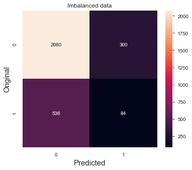

```
Iteration Nº 1 :

Accuracy training with imbalanced data (default threshold=0.5): 70.733333 %
```

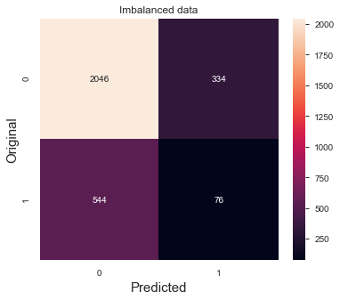

```
Iteration Nº 2 :

Accuracy training with imbalanced data (default threshold=0.5): 72.066665 %
```

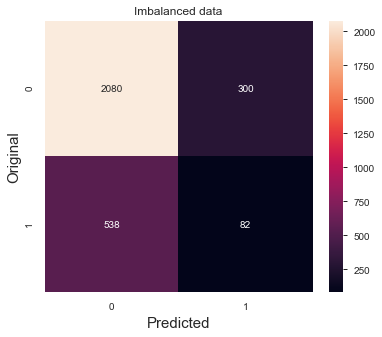

```python
from tensorflow.keras.layers     import Dense, Dropout, BatchNormalization
from tensorflow.keras.utils      import to_categorical
from tensorflow.keras.optimizers import Adam, SGD
from tensorflow.keras.callbacks import ModelCheckpoint
X_train, X_test, y_train, y_test = train_test_split(x, y, test_size = 0.3, random_state = 10)
origDataModel = []  # will contain the #iterations models trained with the original (imbalanced) data
iterations = 3
for i in range(iterations):

  print("Iteration Nº", i, ": \n")

  X_train, X_test, Y_train, Y_test = train_test_split(x, y.ravel(), test_size=0.3)

  model = tf.keras.Sequential()

  model.add(Dense(256, activation='relu'))
  model.add(BatchNormalization())
  model.add(Dropout(0.3))

  model.add(Dense(128,  activation='relu'))
  model.add(BatchNormalization())
  model.add(Dropout(0.3))

  model.add(Dense(64, activation='relu'))
  model.add(BatchNormalization())
  model.add(Dropout(0.3))

  model.add(Dense(32, activation='relu'))
  model.add(BatchNormalization())
  model.add(Dropout(0.3))

  model.add(Dense(8,  activation='relu'))
  model.add(BatchNormalization())
  model.add(Dropout(0.3))

  model.add(Dense(1, activation='sigmoid'))

  model.compile(optimizer=tf.keras.optimizers.Adam(),
                loss='binary_crossentropy',
                metrics=['acc'])

  model_logs = model.fit(X_train,
          Y_train,
          batch_size=32,
          epochs=120,
          verbose=0,  # silent mode
          validation_data=(X_test, Y_test))  # Only to check that the model is not "overfitting" the training data

  origDataModel.append(model)

    # Pseudo-validate with common validation data

  score = model.evaluate(X_test, y_test, verbose=0)  # tensorflow default threshold = 0.5
  print("Accuracy training with imbalanced data (default threshold=0.5): {:-5f} %".format(score[1] * 100))

  Y_pred = model.predict(X_test) > 0.5  # manual threshold
  matConf = confusion_matrix(y_test, Y_pred)
  valsize = y_test.shape[0]

  plt.figure(figsize=(6, 5))  # Establishing the heatmap size before plotting
  ax = sns.heatmap(matConf, annot=True, fmt=".0f")
  ax.set_ylabel('Original', fontsize=15)
  ax.set_xlabel('Predicted', fontsize=15)
  plt.title("Imbalanced data")
  plt.show()
```

```python
model = Sequential()
model.add(Dense(784, input_shape=(12,), activation = 'relu'))
model.add(Dense(100, input_shape=(12,), activation = 'relu'))
model.add(Dense(1, activation = 'softmax'))
sgd = optimizers.Adam(lr = 0.001)
model.compile(optimizer = 'sgd', loss = 'categorical_crossentropy', metrics=['accuracy'])
model.summary()
model.fit(X_train, y_train, batch_size = 100, epochs = 500, verbose = 1)
X_test = preprocessing.normalize(X_test)
results = model.evaluate(X_test, y_test)
print(model.metrics_names)
print(results)
Y_pred_cls = model.predict_classes(X_test, batch_size=200, verbose=0)
print('Accuracy Model1 (Dropout): '+ str(model.evaluate(X_test,y_test)[1]))
print('Recall_score: ' + str(recall_score(y_test,Y_pred_cls)))
print('Precision_score: ' + str(precision_score(y_test, Y_pred_cls)))
print('F-score: ' + str(f1_score(y_test,Y_pred_cls)))
confusion_matrix(y_test, Y_pred_cls)
```

```
Model: "sequential_10"
_________________________________________________________________
Layer (type)                 Output Shape              Param #
=================================================================
dense_48 (Dense)             (None, 784)               10192
_________________________________________________________________
dense_49 (Dense)             (None, 100)               78500
_________________________________________________________________
dense_50 (Dense)             (None, 1)                 101
=================================================================
Total params: 88,793
Trainable params: 88,793
Non-trainable params: 0
_________________________________________________________________
['loss', 'accuracy']
[nan, 0.7933333516120911]
```

```
Accuracy Model1 (Dropout): 0.7933333516120911
Recall_score: 0.0
Precision_score: 0.0
F-score: 0.0
```

```
array([[2380,    0],
       [ 620,    0]])
```

```python
model = Sequential()
model.add(Dense(192, input_shape=(12,), activation = 'relu'))
model.add(Dense(128, input_shape=(12,), activation = 'relu'))
model.add(Dense(64, input_shape=(12,), activation = 'relu'))
model.add(Dense(32, activation = 'tanh'))
model.add(Dense(1, activation = 'softmax'))
sgd = optimizers.Adam(lr = 0.001)
model.compile(optimizer = 'adam', loss = 'categorical_crossentropy', metrics=['accuracy'])
model.summary()
model.fit(X_train, y_train, batch_size = 100, epochs = 300, verbose = 1)
X_test = preprocessing.normalize(X_test)
results = model.evaluate(X_test, y_test)
print(model.metrics_names)
print(results)
Y_pred_cls = model.predict_classes(X_test, batch_size=200, verbose=0)
print('Accuracy Model1 (Dropout): '+ str(model.evaluate(X_test,y_test)[1]))
print('Recall_score: ' + str(recall_score(y_test,Y_pred_cls)))
print('Precision_score: ' + str(precision_score(y_test, Y_pred_cls)))
print('F-score: ' + str(f1_score(y_test,Y_pred_cls)))
confusion_matrix(y_test, Y_pred_cls)
```

```
Model: "sequential_11"
_________________________________________________________________
Layer (type)                 Output Shape              Param #
=================================================================
dense_51 (Dense)             (None, 192)               2496
_________________________________________________________________
dense_52 (Dense)             (None, 128)               24704
_________________________________________________________________
dense_53 (Dense)             (None, 64)                8256
_________________________________________________________________
dense_54 (Dense)             (None, 32)                2080
_________________________________________________________________
dense_55 (Dense)             (None, 1)                 33
=================================================================
Total params: 37,569
Trainable params: 37,569
Non-trainable params: 0
_________________________________________________________________
['loss', 'accuracy']
[0.0, 0.20666666328907013]
```

```
Accuracy Model1 (Dropout): 0.20666666328907013
Recall_score: 1.0
Precision_score: 0.20666666666666667
F-score: 0.3425414364640884
```

```
array([[   0, 2380],
       [   0,  620]])
```

AFTER GOING THOUGH MULTIPLE VARIATIONS IN NN, THE ACCURACY AT THE MOST IS AROUND 81%, AND I WAS NOT ABLE TO IMROVE IT ANY FURTHER